# Natural Language Processing

Natural Language Processing (NLP) is a branch of artificial intelligence that allows computers to understand, interpret and manipulate human language. NLP draws from many disciplines, including computer science and computational linguistics, in its pursuit to fill the gap between human communication and computer understanding.

[figure not shown]

## 1. NLP Pipeline

In all data science processes we have a defined pipeline. In the case of Natural Language Processing, the preprocessing steps differ from how we would approach work with structured data.

[figure not shown]

## 2. Classification in NLP - Twitter Dataset

Twitter is a well-known microblog service from which public data can be collected via APIs. NLTK's twitter corpus currently contains a sample of 20k Tweets retrieved from the Twitter Streaming API.

```python
import re
import string
import itertools
import numpy as np
import pandas as pd
import nltk

import seaborn as sns
import matplotlib.pyplot as plt
import warnings
warnings.filterwarnings("ignore")

# Download dataset
nltk.download('twitter_samples')

from nltk.corpus import stopwords
from nltk.stem import PorterStemmer
from nltk.stem import WordNetLemmatizer
from nltk.tokenize import TweetTokenizer
from nltk.corpus import twitter_samples
from nltk.corpus import wordnet
from nltk.tag import pos_tag_sents

nltk.download('punkt')
nltk.download('stopwords')
nltk.download('wordnet')
nltk.download('averaged_perceptron_tagger')

from sklearn.model_selection import train_test_split
from sklearn.metrics import confusion_matrix

from sklearn.feature_extraction.text import CountVectorizer
from sklearn.feature_extraction.text import TfidfVectorizer
```

We can see how many JSON files exist in the corpus twitter_samples using the `twitter_samples.fileids()` method:

```python
twitter_samples.fileids()
```

```
['negative_tweets.json', 'positive_tweets.json', 'tweets.20150430-223406.json']
```

```python
print('Positive : ',twitter_samples.strings('positive_tweets.json')[0],'\n')
print('Negative : ',twitter_samples.strings('negative_tweets.json')[0])
```

```
Positive :  #FollowFriday @France_Inte @PKuchly57 @Milipol_Paris for being top engaged members in my community this week :)

Negative :  hopeless for tmr :(
```

```python
print('Positive : ',twitter_samples.tokenized('positive_tweets.json')[0],'\n')
print('Negative : ',twitter_samples.tokenized('negative_tweets.json')[0])
```

```
Positive :  ['#FollowFriday', '@France_Inte', '@PKuchly57', '@Milipol_Paris', 'for', 'being', 'top', 'engaged', 'members', 'in', 'my', 'community', 'this', 'week', ':)']

Negative :  ['hopeless', 'for', 'tmr', ':(']
```

```python
positive_tw = twitter_samples.strings('positive_tweets.json')
negative_tw = twitter_samples.strings('negative_tweets.json')
```

```python
print('Positive : ',len(positive_tw))
print('Negative : ',len(negative_tw))
```

```
Positive :  5000
Negative :  5000
```

## 3. Preprocessing Tasks

We have several preprocessing tasks when analyzing text:

- Tokenize

[figure not shown]

- Remove Stop Words
- Clean special characters in text
- Stemming/Lemmatization

[figure not shown]

[Image Source](https://www.slideshare.net/asdkfjqlwef/text-mining-from-bayes-rule-to-de)

We will start by merging the positive and negative tweets into one dataset and give them the tag `pos` or `neg`.

```python
tweets = []
for tweet in positive_tw:
    tweets.append({'tweet':tweet, 'sentiment':'pos'})

# give negative word dictionary 'neg' tag
for tweet in negative_tw:
    tweets.append({'tweet':tweet, 'sentiment':'neg'})
```

```python
pd.DataFrame(tweets).head().append(pd.DataFrame(tweets).tail())
```

|  | tweet | sentiment |
| --- | --- | --- |
| 0 | #FollowFriday @France_Inte @PKuchly57 @Milipol... | pos |
| 1 | @Lamb2ja Hey James! How odd :/ Please call our... | pos |
| 2 | @DespiteOfficial we had a listen last night :)... | pos |
| 3 | @97sides CONGRATS :) | pos |
| 4 | yeaaaah yippppy!!! my accnt verified rqst has... | pos |
| 9995 | I wanna change my avi but uSanele :( | neg |
| 9996 | MY PUPPY BROKE HER FOOT :( | neg |
| 9997 | where's all the jaebum baby pictures :(( | neg |
| 9998 | But but Mr Ahmad Maslan cooks too :( https://t... | neg |
| 9999 | @eawoman As a Hull supporter I am expecting a ... | neg |

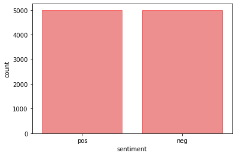

```python
sns.countplot(x='sentiment',  data=pd.DataFrame(tweets), color='red', edgecolor='red', alpha=0.5)
plt.show()
```

### 3.1. Tokenize

Now we need to tokenize the tweet. You can do **sentence tokenize** or **word tokenize**, depending on the type of analysis you're doing. For tweets, you can do a word tokenize by using NLTK's `TweetTokenizer` method.

```python
tokenizer = TweetTokenizer(preserve_case=False, strip_handles=True,reduce_len=True)
print('tweet : ', tweets[0]['tweet'])
tweet_tokens = tokenizer.tokenize(tweets[0]['tweet'])
print('tokenized : ',tweet_tokens)
```

```
tweet :  #FollowFriday @France_Inte @PKuchly57 @Milipol_Paris for being top engaged members in my community this week :)
tokenized :  ['#followfriday', 'for', 'being', 'top', 'engaged', 'members', 'in', 'my', 'community', 'this', 'week', ':)']
```

In the above output, you can see that special characters and the names of Twitter accounts are included in the tweet. These need to be cleaned, which can easily be done by leveraging regular expressions.

We will define a function to process the tweet:

```python
stopwords_english = stopwords.words('english')
print(stopwords_english)
```

```
['i', 'me', 'my', 'myself', 'we', 'our', 'ours', 'ourselves', 'you', "you're", "you've", "you'll", "you'd", 'your', 'yours', 'yourself', 'yourselves', 'he', 'him', 'his', 'himself', 'she', "she's", 'her', 'hers', 'herself', 'it', "it's", 'its', 'itself', 'they', 'them', 'their', 'theirs', 'themselve…
```

```python
def process_tweet(tweet):
    """Process tweet function.
    Input:
        tweet: a string containing a tweet
    Output:
        tweets_clean: a list of words containing the processed tweet
    """
    #stemmer = PorterStemmer()
    stopwords_english = stopwords.words('english')
    tweet = re.sub(r'\$\w*', '', tweet)                    # remove stock market tickers like $GE
    tweet = re.sub(r'^RT[\s]+', '', tweet)                 # remove old style retweet text "RT"
    tweet = re.sub(r'https?:\/\/.*[\r\n]*', '', tweet)     # remove hyperlinks
    tweet = re.sub(r'#', '', tweet)                        # remove hashtags; only removing the hash # sign from the word

    # tokenize tweets
    tokenizer = TweetTokenizer(preserve_case=False, strip_handles=True, reduce_len=True)
    tweet_tokens = tokenizer.tokenize(tweet)

    tweets_clean = []
    for word in tweet_tokens:
        if (word not in stopwords_english and  # remove stopwords
                word not in string.punctuation):  # remove punctuation
            tweets_clean.append(word)
            #stem_word = stemmer.stem(word)  # stemming word
            #tweets_clean.append(stem_word)

    return tweets_clean
```

```python
tweets_pos = []
for tweet in positive_tw:
    tweets_pos.append(process_tweet(tweet))

# give negative word dictionary 'neg' tag
tweets_neg = []
for tweet in negative_tw:
    tweets_neg.append(process_tweet(tweet))
```

```python
tweets_pos[:1]
```

```
[['followfriday', 'top', 'engaged', 'members', 'community', 'week', ':)']]
```

```python
all_tw_pos = list(itertools.chain(*tweets_pos))
all_tw_neg = list(itertools.chain(*tweets_neg))
```

```python
# Most Frecuent words in positive Tweets
freq_all_tw_pos = nltk.FreqDist(all_tw_pos)
freq_all_tw_pos = pd.DataFrame(list(freq_all_tw_pos.items()), columns = ["Word","Frequency"])
freq_all_tw_pos.sort_values('Frequency',ascending=False, inplace = True)
freq_all_tw_pos.reset_index(drop = True, inplace=True)
freq_all_tw_pos.head()
```

|  | Word | Frequency |
| --- | --- | --- |
| 0 | :) | 3568 |
| 1 | :-) | 692 |
| 2 | :D | 629 |
| 3 | thanks | 370 |
| 4 | ... | 289 |

```python
# Most Frecuent words in negative Tweets
freq_all_tw_neg = nltk.FreqDist(all_tw_neg)
freq_all_tw_neg = pd.DataFrame(list(freq_all_tw_neg.items()), columns = ["Word","Frequency"])
freq_all_tw_neg.sort_values('Frequency',ascending=False, inplace = True)
freq_all_tw_neg.reset_index(drop = True, inplace=True)
freq_all_tw_neg.head()
```

|  | Word | Frequency |
| --- | --- | --- |
| 0 | :( | 4571 |
| 1 | :-( | 493 |
| 2 | i'm | 343 |
| 3 | ... | 331 |
| 4 | please | 274 |

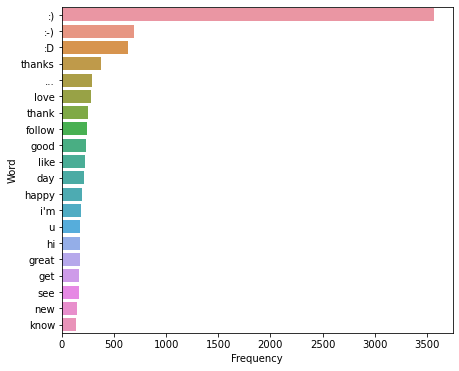

```python
plt.figure(figsize = (7,6))
plot = sns.barplot(x='Frequency', y='Word', data=freq_all_tw_pos.iloc[:20])
plt.show()
```

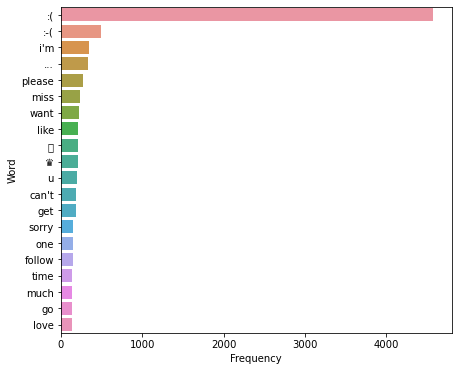

```python
plt.figure(figsize = (7,6))
plot = sns.barplot(x='Frequency', y='Word', data=freq_all_tw_neg.iloc[:20])
# for item in plot.get_xticklabels():
#     item.set_rotation(45)
plt.show()
```

### 3.2. Stemming and Lemmatizing

Now, we will see how `Stemmer` and `Lemmatizer` processes work.

```python
example = "He was running and eating at same time. He has bad habit of swimming after playing long hours in the Sun."
tokens = nltk.word_tokenize(example)
print(tokens)
```

```
['He', 'was', 'running', 'and', 'eating', 'at', 'same', 'time', '.', 'He', 'has', 'bad', 'habit', 'of', 'swimming', 'after', 'playing', 'long', 'hours', 'in', 'the', 'Sun', '.']
```

```python
stemmer    = PorterStemmer()
lemmatizer = WordNetLemmatizer()

# Stem and lemmatize
print("{0:15}{1:15}{2:15}".format("Word","Stemmer","Lemma"))
print("{0:15}{0:15}{0:15}".format("--------"))
for word in tokens:
    print ("{0:15}{1:15}{2:15}".format(word,stemmer.stem(word),lemmatizer.lemmatize(word)))
```

```
Word           Stemmer        Lemma
--------       --------       --------
He             He             He
was            wa             wa
running        run            running
and            and            and
eating         eat            eating
at             at             at
same           same           same
time           time           time
.              .              .
He             He             He
has            ha             ha
bad            bad            bad
habit          habit          habit
of             of             of
swimming       swim           swimming
after          after          after
playing        play           playing
long           long           long
hours          hour           hour
in             in             in
the            the            the
Sun            sun            Sun
.              .              .
```

### 3.3. Post Tagging

For the Lemmatize process, it is important to know what role a word plays in a sentence. In NLTK, we have the method `pos_tag` that return this role.

[figure not shown]

```python
print(nltk.pos_tag(tokens))
```

```
[('He', 'PRP'), ('was', 'VBD'), ('running', 'VBG'), ('and', 'CC'), ('eating', 'VBG'), ('at', 'IN'), ('same', 'JJ'), ('time', 'NN'), ('.', '.'), ('He', 'PRP'), ('has', 'VBZ'), ('bad', 'JJ'), ('habit', 'NN'), ('of', 'IN'), ('swimming', 'NN'), ('after', 'IN'), ('playing', 'VBG'), ('long', 'JJ'), ('hour…
```

```python
print(process_tweet(tweets[0]['tweet']))
print(nltk.pos_tag(process_tweet(tweets[0]['tweet'])))
```

```
['followfriday', 'top', 'engaged', 'members', 'community', 'week', ':)']
[('followfriday', 'JJ'), ('top', 'VB'), ('engaged', 'JJ'), ('members', 'NNS'), ('community', 'NN'), ('week', 'NN'), (':)', 'NN')]
```

Let's define a function that returns the `pos_tag` of a word so that we may use it in the lemmatize process:

```python
def get_wordnet_pos(word):
    """Map POS tag to first character lemmatize() accepts"""
    tag = nltk.pos_tag([word])[0][1][0].upper() # Select first (N) character in second item (NNS) and subitem -> Convert to uppercase
#     print(tag)
    tag_dict = {"J": wordnet.ADJ,
                "N": wordnet.NOUN,
                "V": wordnet.VERB,
                "R": wordnet.ADV}

    return tag_dict.get(tag, wordnet.NOUN)
```

```python
# Converting to the lemma in main branch
print("{0:15}{1:15}{2:15}{3:10}{4:15}".format("Word","Stemmer","Lemma","Type","New Lemma"))
print("{0:15}{0:15}{0:15}{0:10}{0:15}".format("--------"))
for word in tokens:
    print ("{0:15}{1:15}{2:15}{3:10}{4:15}".format(word,
                                                   stemmer.stem(word),
                                                   lemmatizer.lemmatize(word),
                                                   get_wordnet_pos(word),
                                                   lemmatizer.lemmatize(word, get_wordnet_pos(word))))
```

```
Word           Stemmer        Lemma          Type      New Lemma
--------       --------       --------       --------  --------
He             He             He             n         He
was            wa             wa             v         be
running        run            running        v         run
and            and            and            n         and
eating         eat            eating         v         eat
at             at             at             n         at
same           same           same           a         same
time           time           time           n         time
.              .              .              n         .
He             He             He             n         He
has            ha             ha             v         have
bad            bad            bad            a         bad
habit          habit          habit          n         habit
of             of             of             n         of
swimming       swim           swimming       v         swim
after          after          after          n         after
playing        play           playing        v         play
long           long           long           r         long
hours          hour           hour           n         hour
in             in             in             n         in
the            the            the            n         the
Sun            sun            Sun            n         Sun
.              .              .              n         .
```

```python
def process_tweet(tweet,stem = False, lemma= False, own_stop_words=[]):
    """Process tweet function.
    Input:
        tweet: a string containing a tweet
    Output:
        tweets_clean: a list of words containing the processed tweet
    """
    stopwords_english = stopwords.words('english')
    stopwords_new = stopwords_english + own_stop_words

    tweet = re.sub(r'\$\w*', '', tweet)                    # remove stock market tickers like $GE
    tweet = re.sub(r'^RT[\s]+', '', tweet)                 # remove old style retweet text "RT"
    tweet = re.sub(r'https?:\/\/.*[\r\n]*', '', tweet)     # remove hyperlinks
    tweet = re.sub(r'#', '', tweet)                        # remove hashtags; only removing the hash # sign from the word

    # tokenize tweets
    tokenizer = TweetTokenizer(preserve_case=False, strip_handles=True, reduce_len=True)
    tweet_tokens = tokenizer.tokenize(tweet)

    tweets_clean = []
    for word in tweet_tokens:
        if (word not in stopwords_new and  # remove stopwords
                word not in string.punctuation):            # remove punctuation
            if lemma is False and stem is False:
                tweets_clean.append(word)
            elif lemma is False and stem is True:
                stem_word  = PorterStemmer().stem(word)      # stemming word
                tweets_clean.append(stem_word)
            elif lemma is True and stem is False:
                lemma_word = WordNetLemmatizer().lemmatize(word, get_wordnet_pos(word)) # Lemmatize to the main branch
                tweets_clean.append(lemma_word)
    return tweets_clean
```

```python
own_stop_words = ["i'm","follow","u"]
tweets = []
for tweet in positive_tw:
    tweets.append({'tweet':' '.join(process_tweet(tweet, lemma=True, own_stop_words=own_stop_words)), 'sentiment':'pos'})

# give negative word dictionary 'neg' tag
for tweet in negative_tw:
    tweets.append({'tweet':' '.join(process_tweet(tweet, lemma=True, own_stop_words=own_stop_words)), 'sentiment':'neg'})
```

```python
data = pd.DataFrame(tweets)
data[['sentiment']] = data[['sentiment']].replace({'pos':1,'neg':0})
data.head().append(data.tail())
```

|  | tweet | sentiment |
| --- | --- | --- |
| 0 | followfriday top engage member community week :) | 1 |
| 1 | hey james odd :/ please call contact centre 02... | 1 |
| 2 | listen last night :) bleed amaze track scotland | 1 |
| 3 | congrats :) | 1 |
| 4 | yeaaah yipppy accnt verify rqst succeed get bl... | 1 |
| 9995 | wanna change avi usanele :( | 0 |
| 9996 | puppy broke foot :( | 0 |
| 9997 | where's jaebum baby picture :( | 0 |
| 9998 | mr ahmad maslan cook :( | 0 |
| 9999 | hull supporter expect misserable week :-( | 0 |

```python
# Convert tweets to list
list_tweets = list(data['tweet'].values)
sentiment   = data['sentiment'].values
```

```python
list_tweets[:2]
```

```
['followfriday top engage member community week :)',
 'hey james odd :/ please call contact centre 02392441234 able assist :) many thanks']
```

```python
sentiment[:2]
```

```
array([1, 1], dtype=int64)
```

### 3.4. Convert to Custom Dictionary

`CountVectorizer` provides a simple way to both tokenize a collection of text documents and build a vocabulary of known words. Using this vocabulary, you can also use `CountVectorizer` to encode new documents.

```python
# define max features
max_features=100   # each instance will have 10 features

count_vector     = CountVectorizer(max_features=max_features, ngram_range=(1, 2)) # stop_words="english" , ngram_range=(1, 2)
matrix_tweets_cv = count_vector.fit_transform(list_tweets)
# getting the words
all_words        = count_vector.get_feature_names()

# visualize first 50 words
print("First 50 words: ",all_words[0:50])
```

```
First 50 words:  ['always', 'back', 'bad', 'best', 'birthday', 'can', 'come', 'could', 'day', 'enjoy', 'even', 'everyone', 'feel', 'follow', 'friday', 'friend', 'fuck', 'fun', 'get', 'give', 'go', 'good', 'great', 'guy', 'happy', 'help', 'hey', 'hi', 'home', 'hope', 'im', 'keep', 'kik', 'know', 'las…
```

```python
print(count_vector.vocabulary_)
```

```
{'week': 91, 'hey': 26, 'please': 57, 'thanks': 75, 'last': 34, 'night': 52, 'get': 18, 'day': 8, 'one': 54, 'like': 37, 'keep': 31, 'wait': 85, 'hope': 29, 'enjoy': 9, 'happy': 24, 'friday': 14, 'time': 79, 'new': 49, 'go': 20, 'well': 93, 'love': 42, 'know': 33, 'great': 22, 'today': 80, 'friend':…
```

```python
matrix_tweets_cv.toarray()[-3:]
```

```
array([[0, 0, 0, 0, 0, 0, 0, 0, 0, 0, 0, 0, 0, 0, 0, 0, 0, 0, 0, 0, 0, 0,
        0, 0, 0, 0, 0, 0, 0, 0, 0, 0, 0, 0, 0, 0, 0, 0, 0, 0, 0, 0, 0, 0,
        0, 0, 0, 0, 0, 0, 0, 0, 0, 0, 0, 0, 0, 0, 0, 0, 0, 0, 0, 0, 0, 0,
        0, 0, 0, 0, 0, 0, 0, 0, 0, 0, 0, 0, 0, 0, 0, 0, 0, 0, 0, 0, 0, 0,
        0, 0, 0, 0, 0, 0, 0, 0, 0, 0, 0, 0],
       [0, 0, 0, 0, 0, 0, 0, 0, 0, 0, 0, 0, 0, 0, 0, 0, 0, 0, 0, 0, 0, 0,
        0, 0, 0, 0, 0, 0, 0, 0, 0, 0, 0, 0, 0, 0, 0, 0, 0, 0, 0, 0, 0, 0,
        0, 0, 0, 0, 0, 0, 0, 0, 0, 0, 0, 0, 0, 0, 0, 0, 0, 0, 0, 0, 0, 0,
        0, 0, 0, 0, 0, 0, 0, 0, 0, 0, 0, 0, 0, 0, 0, 0, 0, 0, 0, 0, 0, 0,
        0, 0, 0, 0, 0, 0, 0, 0, 0, 0, 0, 0],
       [0, 0, 0, 0, 0, 0, 0, 0, 0, 0, 0, 0, 0, 0, 0, 0, 0, 0, 0, 0, 0, 0,
        0, 0, 0, 0, 0, 0, 0, 0, 0, 0, 0, 0, 0, 0, 0, 0, 0, 0, 0, 0, 0, 0,
        0, 0, 0, 0, 0, 0, 0, 0, 0, 0, 0, 0, 0, 0, 0, 0, 0, 0, 0, 0, 0, 0,
        0, 0, 0, 0, 0, 0, 0, 0, 0, 0, 0, 0, 0, 0, 0, 0, 0, 0, 0, 0, 0, 0,
        0, 0, 0, 1, 0, 0, 0, 0, 0, 0, 0, 0]], dtype=int64)
```

```python
x = matrix_tweets_cv.toarray()
y = sentiment

train_x, test_x, train_y, test_y = train_test_split(x, y, test_size=0.2, random_state=42, stratify=y)
```

```python
print(train_x.shape)
print(test_x.shape)
```

```
(8000, 100)
(2000, 100)
```

```python
(unique, counts) = np.unique(train_y, return_counts=True)
frequencies      = np.asarray((unique, counts)).T
print(frequencies)
```

```
[[   0 4000]
 [   1 4000]]
```

```python
(unique, counts) = np.unique(test_y, return_counts=True)
frequencies      = np.asarray((unique, counts)).T
print(frequencies)
```

```
[[   0 1000]
 [   1 1000]]
```

## 4. Modelling

Now experimenting with models.

```python
def confusion(ytest,y_pred):
    names=["Negative","Positive"]
    cm=confusion_matrix(ytest,y_pred)
    f,ax=plt.subplots(figsize=(6,6))
    sns.heatmap(cm,annot=True,linewidth=.5, linecolor="b", fmt=".0f", cmap = 'Blues', ax=ax)
    plt.xlabel(r"$\mathrm{y_{pred}}$"); plt.ylabel(r"$\mathrm{y_{true}}$")
    ax.set_xticklabels(names); ax.set_yticklabels(names)
    plt.show()
    return
```

### 4.1. Naive Bayes

```python
from sklearn.naive_bayes import GaussianNB

nb = GaussianNB().fit(train_x,train_y)
print("Accuracy:", nb.score(test_x,test_y))
```

```
Accuracy: 0.666
```

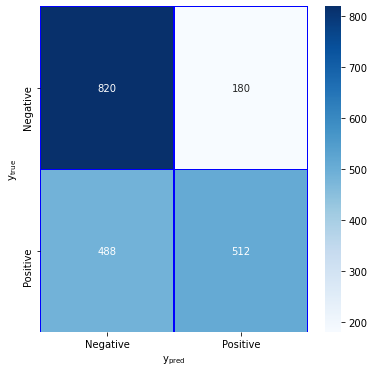

```python
y_pred=nb.predict(test_x)
confusion(test_y,y_pred)
```

### 4.2. TF-IDF

Word counts are a good starting point but are very basic. One issue with simple counts is that some words like “the” will appear many times and their large count values will not be very meaningful in the encoded vectors.

An alternative is to calculate word frequencies. The most popular way of doing this is called $\mathrm{TF\text{-}IDF}_{i,j}$. This is an acronym that stands for “Term Frequency – Inverse Document Frequency". It is calculated as so:

$$\mathrm{TF\text{-}IDF}_{i,j} = \mathrm{TF}_{i,j} \times \log{\frac{N}{\mathrm{df}_{i}}}$$

Where $\mathrm{TF}_{i,j}$ is the total number of occurrences of $i$ in $j$, $\mathrm{df}_{i}$ total number of documents (speeches) containing $i$; $\mathrm{N}$ total number of documents (speeches).

```python
vectorizer = TfidfVectorizer(max_features=max_features, ngram_range=(1, 2))
matrix_tweets_tf = vectorizer.fit_transform(list_tweets)

# getting the words
all_words = vectorizer.get_feature_names()

# visualize first 50 words
print("First 50 words: ",all_words[0:50])
```

```
First 50 words:  ['always', 'back', 'bad', 'best', 'birthday', 'can', 'come', 'could', 'day', 'enjoy', 'even', 'everyone', 'feel', 'follow', 'friday', 'friend', 'fuck', 'fun', 'get', 'give', 'go', 'good', 'great', 'guy', 'happy', 'help', 'hey', 'hi', 'home', 'hope', 'im', 'keep', 'kik', 'know', 'las…
```

```python
print(vectorizer.vocabulary_)
```

```
{'week': 91, 'hey': 26, 'please': 57, 'thanks': 75, 'last': 34, 'night': 52, 'get': 18, 'day': 8, 'one': 54, 'like': 37, 'keep': 31, 'wait': 85, 'hope': 29, 'enjoy': 9, 'happy': 24, 'friday': 14, 'time': 79, 'new': 49, 'go': 20, 'well': 93, 'love': 42, 'know': 33, 'great': 22, 'today': 80, 'friend':…
```

```python
x = matrix_tweets_tf.toarray()
y = sentiment

train_x, test_x, train_y, test_y = train_test_split(x,y,test_size=0.2,random_state=42,stratify=y)
```

```python
from sklearn.naive_bayes import GaussianNB

nb = GaussianNB().fit(train_x,train_y)

print("Accuracy: ", nb.score(test_x,test_y))
```

```
Accuracy:  0.6615
```

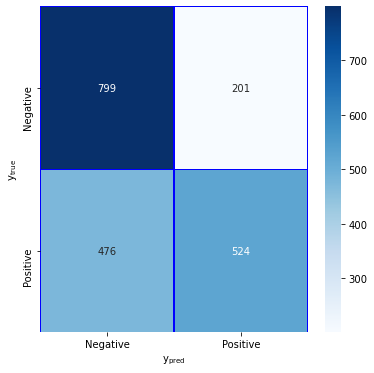

```python
y_pred=nb.predict(test_x)
confusion(test_y,y_pred)
```

### 4.3. SVM

```python
from sklearn.svm import LinearSVC
svc = LinearSVC(C = 1).fit(train_x,train_y)
print("Accuracy: ", svc.score(test_x,test_y))
```

```
Accuracy:  0.67
```

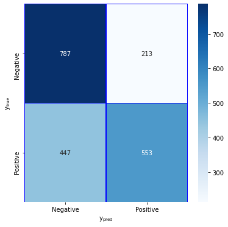

```python
y_pred=svc.predict(test_x)
confusion(test_y, y_pred)
```

### 4.4. Random Forest

```python
from sklearn.ensemble import RandomForestClassifier
from sklearn.metrics import confusion_matrix

rf = RandomForestClassifier(n_estimators = 50, random_state=42).fit(train_x,train_y)
print("Accuracy: ", rf.score(test_x,test_y))
```

```
Accuracy:  0.6585
```

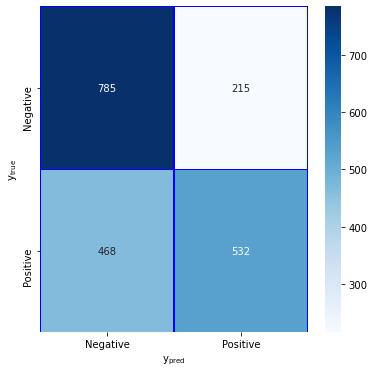

```python
y_pred=rf.predict(test_x)
confusion(test_y,y_pred)
```

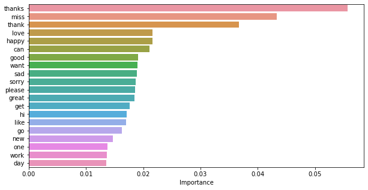

```python
importances = rf.feature_importances_

all_words = vectorizer.get_feature_names()
columns = all_words

# Sort by importance and take the first 20
indices = np.argsort(importances)[::-1]
indices = indices[:20]
selected_columns = [columns[i] for i in indices]
selected_importances = importances[indices]

# Graph the results
plt.figure(figsize = (10,5))
sns.barplot(selected_importances, selected_columns)
plt.xlabel('Importance')
plt.show()
```

### 4.5. Tunning

```python
# max_features
y = sentiment
M1_list = []; M2_list = []; M3_list = []

for m_features in np.linspace(50, 500, 51, dtype=int):
    vectorizer = TfidfVectorizer(max_features = m_features, ngram_range=(1, 2))
    matrix_tweets_tf = vectorizer.fit_transform(list_tweets)
    x = matrix_tweets_tf.toarray()
    train_x, test_x, train_y, test_y = train_test_split(x,y,test_size=0.2,random_state=42,stratify=y)

    # Modelling
    svc = LinearSVC(C = 1).fit(train_x,train_y)
    nb  = GaussianNB().fit(train_x,train_y)
    rf  = RandomForestClassifier(n_estimators = 50, random_state=42).fit(train_x,train_y)

    M1_list.append(rf.score(test_x,test_y))
    M2_list.append(nb.score(test_x,test_y))
    M3_list.append(svc.score(test_x,test_y))

N_Features_DF = pd.DataFrame({
    'N_Features'  : np.linspace(50, 500, 51, dtype=int),
    'RF_accuracy' : M1_list,
    'NB_accuracy' : M2_list,
    'SVC_accuracy': M3_list
})
```

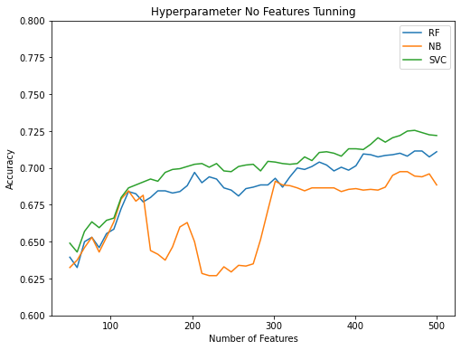

```python
fig, ax = plt.subplots(figsize=(8,6))
sns.lineplot(x='N_Features', y='RF_accuracy', data = N_Features_DF, ax=ax, label='RF')
sns.lineplot(x='N_Features', y='NB_accuracy', data = N_Features_DF, ax=ax, label='NB')
sns.lineplot(x='N_Features', y='SVC_accuracy', data = N_Features_DF, ax=ax, label='SVC')
ax.set(xlabel='Number of Features', ylabel = 'Accuracy', title='Hyperparameter No Features Tunning', ylim=(0.6, 0.8));
```

We can see here that there is not a significant gain on Accuracy with an increase in the number of features, we can see that 120 features are ok for most of the models.

```python
np.linspace(1, 6, 6, dtype=int)
```

```
array([1, 2, 3, 4, 5, 6])
```

```python
y = sentiment
M1_list = []; M2_list = []; M3_list = []

for i in np.linspace(1, 6, 6, dtype=int):
    vectorizer = TfidfVectorizer(max_features = 120, ngram_range=(i, i))
    matrix_tweets_tf = vectorizer.fit_transform(list_tweets)
    x = matrix_tweets_tf.toarray()
    train_x, test_x, train_y, test_y = train_test_split(x,y,test_size=0.2,random_state=42,stratify=y)

    # Modelling
    svc = LinearSVC(C = 1).fit(train_x,train_y)
    nb  = GaussianNB().fit(train_x,train_y)
    rf  = RandomForestClassifier(n_estimators = 50, random_state=42).fit(train_x,train_y)

    M1_list.append(rf.score(test_x,test_y))
    M2_list.append(nb.score(test_x,test_y))
    M3_list.append(svc.score(test_x,test_y))

N_grams_Range_DF = pd.DataFrame({
    'Max_Ngrams'  : np.linspace(1,6,6, dtype=int),
    'RF_accuracy' : M1_list,
    'NB_accuracy' : M2_list,
    'SVC_accuracy': M3_list
})
```

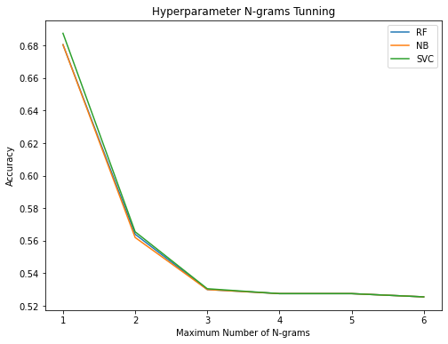

```python
fig, ax = plt.subplots(figsize=(8,6))
sns.lineplot(x='Max_Ngrams', y='RF_accuracy', data = N_grams_Range_DF, ax=ax, label='RF')
sns.lineplot(x='Max_Ngrams', y='NB_accuracy', data = N_grams_Range_DF, ax=ax, label='NB')
sns.lineplot(x='Max_Ngrams', y='SVC_accuracy', data = N_grams_Range_DF, ax=ax, label='SVC')
ax.set(xlabel='Maximum Number of N-grams', ylabel = 'Accuracy', title='Hyperparameter N-grams Tunning');
```